# Ribo-seQC vignette

Lorenzo Calviello

22 June, 2020

## Introduction

Ribo-seQC is a package that performs quality control analysis of small RNA-seq data (in .bam format), with a focus on Ribo-seq [1] and related techniques. Thanks to syntax and functions present in packages like *GenomicFeatures*, *rtracklayer* or *BSgenome*, this package can perform comprehensive analyses of alignments on a variety of genomic regions. This vignette illustrates the usage of the package using example data and annotation from three different experiments performed in three different organisms.

**Warning**: While we encourage users to get familiar with each outlined step, executing all the code on your machine will generate a lot of data (~550 Mb) and it might take some time (5-10 minutes for each analysis and report creation). Please make sure to have enough disk space if you decide to execute code from all the sections.

As a first step, let’s load the package:

```r
suppressPackageStartupMessages(library("RiboseQC"))
```

## Exploring the annotation

Let’s now download annotation for *Homo sapiens*: a subset of the GENCODE 25 annotation (https://www.gencodegenes.org/human/release_25.html) and the corresponding genome sequences.

```r
download_testfile = function(filename){
    download.file(paste0("http://bimsbstatic.mdc-berlin.de/ohler/dharnet/riboseqc_testfiles/",filename),destfile = filename)
}
download_testfile(filename = "test_human.2bit")

download_testfile(filename = "test_human.gtf")
```

To parse the rich information present in our *.gtf* file we use the *prepare_annotation_files* function. Such a function creates a *TxDb* and a compressed *Rdata* file containing several regions of interest and additional information. Moreover, such function reads a genome file in *.2bit* to forge a *BSgenome* package for fast and efficient query of genomic sequences. A *.2bit* file can be obtained from a *.fasta* file using the *faToTwoBit* software from UCSC: https://genome.ucsc.edu/goldenpath/help/twoBit.html - http://hgdownload.soe.ucsc.edu/admin/exe/ )

```r
prepare_annotation_files(annotation_directory = ".",
                         twobit_file = "test_human.2bit",
                         gtf_file = "test_human.gtf",scientific_name = "Human.test",
                         annotation_name = "genc25_22M",export_bed_tables_TxDb = F,forge_BSgenome = T,create_TxDb = T)
```

[output not shown]

[output cut: 232 more lines]

[output not shown]

```
## Import genomic features from the file as a GRanges object ... OK
## Prepare the 'metadata' data frame ... OK
## Make the TxDb object ...
```

```
## OK
```

```
## Creating the TxDb object --- Done! Mon Jun 22 11:51:47 2020
## Extracting genomic regions ... Mon Jun 22 11:51:47 2020
## Extracting ids and biotypes ... Mon Jun 22 11:51:54 2020
## Defining most common start/stop codons ... Mon Jun 22 11:51:58 2020
## Rannot object created!   Mon Jun 22 11:52:03 2020
```

```
## [1] "/fast/AG_Ohler/dharnet/Ribo-seQC/test_human.gtf_Rannot"
```

We can now read such information using the *load_annotation* function:

```r
load_annotation("test_human.gtf_Rannot")
```

Two objects have now been created: a *genome_seq* object links to the *BSgenome* package we just created and loaded (containing genome sequences), and a *GTF_annotation* object containing important information present in our *.gtf* file. For instance, we can access genomic sequences using commands as:

```r
genome_seq[["chr22"]]
```

```
##   50818468-letter "DNAString" instance
## seq: NNNNNNNNNNNNNNNNNNNNNNNNNNNNNNNNNNNN...NNNNNNNNNNNNNNNNNNNNNNNNNNNNNNNNNNNN
```

```r
genome_seq[["chrM"]]
```

```
##   16569-letter "DNAString" instance
## seq: GATCACAGGTCTATCACCCTATTAACCACTCACGGG...AGCCCACACGTTCCCCTTAAATAAGACATCACGATG
```

Transcript annotation and CDS annotations can be accessed as follows:

```r
GTF_annotation$exons_txs
```

```
## GRangesList object of length 4509:
## $ENST00000624155.1
## GRanges object with 2 ranges and 3 metadata columns:
##       seqnames            ranges strand |   exon_id         exon_name exon_rank
##          <Rle>         <IRanges>  <Rle> | <integer>       <character> <integer>
##   [1]    chr22 11066501-11066515      + |         1 ENSE00003758096.1         1
##   [2]    chr22 11067985-11068089      + |         2 ENSE00003758861.1         2
##   -------
##   seqinfo: 2 sequences (1 circular) from an unspecified genome
##
## $ENST00000422332.1
## GRanges object with 2 ranges and 3 metadata columns:
##       seqnames            ranges strand |   exon_id         exon_name exon_rank
##          <Rle>         <IRanges>  <Rle> | <integer>       <character> <integer>
##   [1]    chr22 11124337-11124379      + |         3 ENSE00001616995.1         1
##   [2]    chr22 11124508-11125705      + |         4 ENSE00001776473.1         2
##   -------
##   seqinfo: 2 sequences (1 circular) from an unspecified genome
##
## $ENST00000634617.1
## GRanges object with 9 ranges and 3 metadata columns:
##       seqnames            ranges strand |   exon_id         exon_name exon_rank
##          <Rle>         <IRanges>  <Rle> | <integer>       <character> <integer>
##   [1]    chr22 12602466-12602527      + |         5 ENSE00003784219.1         1
##   [2]    chr22 12604670-12604739      + |         6 ENSE00003784834.1         2
##   [3]    chr22 12615409-12615534      + |         7 ENSE00003785913.1         3
##   [4]    chr22 12616314-12616371      + |         8 ENSE00003790031.1         4
##   [5]    chr22 12618171-12618289      + |         9 ENSE00003786552.1         5
##   [6]    chr22 12620838-12620938      + |        10 ENSE00003788654.1         6
##   [7]    chr22 12624242-12624331      + |        11 ENSE00003791453.1         7
##   [8]    chr22 12625317-12625428      + |        12 ENSE00003788301.1         8
##   [9]    chr22 12626607-12626642      + |        13 ENSE00003788969.1         9
##   -------
##   seqinfo: 2 sequences (1 circular) from an unspecified genome
##
## ...
## <4506 more elements>
```

```r
GTF_annotation$cds_txs
```

```
## GRangesList object of length 2112:
## $ENST00000624155.1
## GRanges object with 2 ranges and 3 metadata columns:
##       seqnames            ranges strand |    cds_id    cds_name exon_rank
##          <Rle>         <IRanges>  <Rle> | <integer> <character> <integer>
##   [1]    chr22 11066501-11066515      + |         1        <NA>         1
##   [2]    chr22 11067985-11068089      + |         2        <NA>         2
##   -------
##   seqinfo: 2 sequences (1 circular) from an unspecified genome
##
## $ENST00000252835.4
## GRanges object with 1 range and 3 metadata columns:
##       seqnames            ranges strand |    cds_id    cds_name exon_rank
##          <Rle>         <IRanges>  <Rle> | <integer> <character> <integer>
##   [1]    chr22 15528159-15529139      + |         3        <NA>         1
##   -------
##   seqinfo: 2 sequences (1 circular) from an unspecified genome
##
## $ENST00000343518.10
## GRanges object with 10 ranges and 3 metadata columns:
##        seqnames            ranges strand |    cds_id    cds_name exon_rank
##           <Rle>         <IRanges>  <Rle> | <integer> <character> <integer>
##    [1]    chr22 15690078-15690709      + |         5        <NA>         1
##    [2]    chr22 15695371-15695485      + |         8        <NA>         2
##    [3]    chr22 15695645-15695818      + |         9        <NA>         3
##    [4]    chr22 15698662-15698768      + |        11        <NA>         4
##    [5]    chr22 15700078-15700215      + |        12        <NA>         5
##    [6]    chr22 15702686-15702756      + |        13        <NA>         6
##    [7]    chr22 15708020-15708090      + |        14        <NA>         7
##    [8]    chr22 15709782-15709826      + |        15        <NA>         8
##    [9]    chr22 15710868-15711034      + |        16        <NA>         9
##   [10]    chr22 15719660-15719777      + |        17        <NA>        10
##   -------
##   seqinfo: 2 sequences (1 circular) from an unspecified genome
##
## ...
## <2109 more elements>
```

The genomic sequences corresponding to such genomic regions can be easily extracted:

```r
getSeq(genome_seq,GTF_annotation$cds_txs[[4]])
```

```
##   A DNAStringSet instance of length 11
##      width seq
##  [1]   237 ATGGTGGCTGAGGCTGGTTCAATGCCGGCTGCC...TTCCCCTGGTGCAGGGGGAGCGGCAAGAGCAAC
##  [2]   284 GTGGGCACTTCTGGAGACCACGACGACTCTGCT...CACTGACATGAACAAGAAGGACAAGCAAAAGAG
##  [3]   115 GACTGCTCTACATCTGGCCTCTGCCAATGGAAA...CTTGACAACAAAAAGAGGACAGCTCTGACAAAG
##  [4]   174 GCCGTACAATGCCAGGAAGATGAATGTGCGTTA...TTATACGGTGCTGATATCGAATCAAAAAACAAG
##  [5]   107 CATGGCCTCACACCACTGTTACTTGGTGTACAT...AGCAAATTTAAATGCACTGGATAGATATGGAAG
##  ...   ... ...
##  [7]    71 AATTTGCCAGTTACTTTCTGACTACAAAGAAAA...TACTAAAAGTCTCTTCTGAAAACAGCAATCCAG
##  [8]    71 AACAAGACTTAAAGCTGACATCAGAGGAAGAGT...AGGCTTAAAGGAAGTGAAAATAGCCAGCCAGAG
##  [9]    45 GAAATGTCTCAAGAACCAGAAATAAATAAGGGTGGTGATAGAAAG
## [10]   167 GTTGAAGAAGAAATGAAGAAGCACGGAAGTACT...ATTTCCTGACACTGAGAATGAACAGTATCACAG
## [11]   118 TGATGAACAAAATGATACTCAGAAGCAACTTTC...AAGCAGATAGAAGTGGCTGAAAATGAATTCTGA
```

A list of annotated start and stop codons, including the transcripts they map to, can be accessed using:

```r
GTF_annotation$start_stop_codons
```

```
## GRanges object with 2338 ranges and 6 metadata columns:
##          seqnames    ranges strand |            type
##             <Rle> <IRanges>  <Rle> | <CharacterList>
##      [1]    chr22  11066501      + |     start_codon
##      [2]    chr22  11068087      + |      stop_codon
##      [3]    chr22  15528159      + |     start_codon
##      [4]    chr22  15529137      + |      stop_codon
##      [5]    chr22  15690078      + |     start_codon
##      ...      ...       ...    ... .             ...
##   [2334]     chrM     14146      + |      stop_codon
##   [2335]     chrM     14747      + |     start_codon
##   [2336]     chrM     15885      + |      stop_codon
##   [2337]     chrM     14151      - |      stop_codon
##   [2338]     chrM     14673      - |     start_codon
##                                 transcript_id            gene_id
```

[output cut: 27 more lines]

CDS annotation in transcript-level coordinates is also reported:

```r
GTF_annotation$cds_txs_coords
```

```
## GRanges object with 2112 ranges and 7 metadata columns:
##                                seqnames    ranges strand |            gene_id
##                                   <Rle> <IRanges>  <Rle> |        <character>
##    ENST00000624155.1  ENST00000624155.1     1-120      + |  ENSG00000279973.1
##    ENST00000252835.4  ENST00000252835.4     2-982      + |  ENSG00000130538.4
##   ENST00000343518.10 ENST00000343518.10   53-1690      + | ENSG00000198062.14
##    ENST00000621704.4  ENST00000621704.4    1-1527      + | ENSG00000198062.14
##    ENST00000452800.1  ENST00000452800.1     1-912      + | ENSG00000198062.14
##                  ...                ...       ...    ... .                ...
##    ENST00000361335.1  ENST00000361335.1     1-297      + |  ENSG00000212907.2
##    ENST00000361381.2  ENST00000361381.2    1-1378      + |  ENSG00000198886.2
##    ENST00000361567.2  ENST00000361567.2    1-1812      + |  ENSG00000198786.2
##    ENST00000361789.2  ENST00000361789.2    1-1141      + |  ENSG00000198727.2
##    ENST00000361681.2  ENST00000361681.2     1-525      - |  ENSG00000198695.2
##                      upstr_stasto mostfreq_stasto     lentx
##                         <integer>       <integer> <integer>
##    ENST00000624155.1            2               2       120
##    ENST00000252835.4            2               2       982
##   ENST00000343518.10            2               2      1928
##    ENST00000621704.4            2               2      1874
##    ENST00000452800.1            0               0      1964
##                  ...          ...             ...       ...
##    ENST00000361335.1            2               2       297
##    ENST00000361381.2            2               2      1378
##    ENST00000361567.2            2               2      1812
##    ENST00000361789.2            2               2      1141
##    ENST00000361681.2            2               2       525
##                      reprentative_mostcommon reprentative_boundaries
##                                    <logical>               <logical>
##    ENST00000624155.1                    TRUE                    TRUE
##    ENST00000252835.4                    TRUE                    TRUE
##   ENST00000343518.10                    TRUE                    TRUE
##    ENST00000621704.4                   FALSE                   FALSE
##    ENST00000452800.1                   FALSE                   FALSE
##                  ...                     ...                     ...
##    ENST00000361335.1                    TRUE                    TRUE
##    ENST00000361381.2                    TRUE                    TRUE
##    ENST00000361567.2                    TRUE                    TRUE
##    ENST00000361789.2                    TRUE                    TRUE
##    ENST00000361681.2                    TRUE                    TRUE
##                      reprentative_5len
##                              <logical>
##    ENST00000624155.1              TRUE
##    ENST00000252835.4              TRUE
##   ENST00000343518.10              TRUE
##    ENST00000621704.4             FALSE
##    ENST00000452800.1             FALSE
##                  ...               ...
##    ENST00000361335.1              TRUE
##    ENST00000361381.2              TRUE
##    ENST00000361567.2              TRUE
##    ENST00000361789.2              TRUE
##    ENST00000361681.2              TRUE
##   -------
##   seqinfo: 2112 sequences from an unspecified genome
```

A list of gene ids, transcript ids, together with their symbols and biotypes, can be accessed with:

```r
GTF_annotation$trann
```

```
## DataFrame with 4509 rows and 5 columns
##                gene_id           gene_biotype   gene_name     transcript_id
##            <character>            <character> <character>       <character>
## 1    ENSG00000277248.1                  snRNA          U2 ENST00000615943.1
## 2    ENSG00000283047.1 unprocessed_pseudogene      FRG1FP ENST00000635667.1
## 3    ENSG00000280363.1         protein_coding  CU104787.1 ENST00000623473.1
## 4    ENSG00000279973.1         protein_coding       BAGE5 ENST00000624155.1
## 5    ENSG00000226444.2   processed_pseudogene    ACTR3BP6 ENST00000422332.1
## ...                ...                    ...         ...               ...
## 4505 ENSG00000198695.2         protein_coding      MT-ND6 ENST00000361681.2
## 4506 ENSG00000210194.1                Mt_tRNA       MT-TE ENST00000387459.1
## 4507 ENSG00000198727.2         protein_coding      MT-CYB ENST00000361789.2
## 4508 ENSG00000210195.2                Mt_tRNA       MT-TT ENST00000387460.2
## 4509 ENSG00000210196.2                Mt_tRNA       MT-TP ENST00000387461.2
##          transcript_biotype
##                 <character>
## 1                     snRNA
## 2    unprocessed_pseudogene
## 3            protein_coding
## 4            protein_coding
## 5      processed_pseudogene
## ...                     ...
## 4505         protein_coding
## 4506                Mt_tRNA
## 4507         protein_coding
## 4508                Mt_tRNA
## 4509                Mt_tRNA
```

The genetic codes used for each chromosomes are accessed using:

```r
GTF_annotation$genetic_codes
```

```
##       seqlengths isCircular genome genetic_code
## chr22   50818468         NA   <NA>            1
## chrM       16569       TRUE   <NA>            2
```

```r
getGeneticCode(GTF_annotation$genetic_codes["chr22","genetic_code"])
```

```
## TTT TTC TTA TTG TCT TCC TCA TCG TAT TAC TAA TAG TGT TGC TGA TGG CTT CTC CTA CTG
## "F" "F" "L" "L" "S" "S" "S" "S" "Y" "Y" "*" "*" "C" "C" "*" "W" "L" "L" "L" "L"
## CCT CCC CCA CCG CAT CAC CAA CAG CGT CGC CGA CGG ATT ATC ATA ATG ACT ACC ACA ACG
## "P" "P" "P" "P" "H" "H" "Q" "Q" "R" "R" "R" "R" "I" "I" "I" "M" "T" "T" "T" "T"
## AAT AAC AAA AAG AGT AGC AGA AGG GTT GTC GTA GTG GCT GCC GCA GCG GAT GAC GAA GAG
## "N" "N" "K" "K" "S" "S" "R" "R" "V" "V" "V" "V" "A" "A" "A" "A" "D" "D" "E" "E"
## GGT GGC GGA GGG
## "G" "G" "G" "G"
## attr(,"alt_init_codons")
## [1] "TTG" "CTG"
```

```r
getGeneticCode(GTF_annotation$genetic_codes["chrM","genetic_code"])
```

```
## TTT TTC TTA TTG TCT TCC TCA TCG TAT TAC TAA TAG TGT TGC TGA TGG CTT CTC CTA CTG
## "F" "F" "L" "L" "S" "S" "S" "S" "Y" "Y" "*" "*" "C" "C" "W" "W" "L" "L" "L" "L"
## CCT CCC CCA CCG CAT CAC CAA CAG CGT CGC CGA CGG ATT ATC ATA ATG ACT ACC ACA ACG
## "P" "P" "P" "P" "H" "H" "Q" "Q" "R" "R" "R" "R" "I" "I" "M" "M" "T" "T" "T" "T"
## AAT AAC AAA AAG AGT AGC AGA AGG GTT GTC GTA GTG GCT GCC GCA GCG GAT GAC GAA GAG
## "N" "N" "K" "K" "S" "S" "*" "*" "V" "V" "V" "V" "A" "A" "A" "A" "D" "D" "E" "E"
## GGT GGC GGA GGG
## "G" "G" "G" "G"
## attr(,"alt_init_codons")
## [1] "ATT" "ATC" "GTG"
```

Annotation and genome sequences are linked together in the annotation creation step. The BSgenome package corresponding to the .gtf file used is reported in the *GTF_annotation* object:

```r
GTF_annotation$genome_package
```

```
## [1] "BSgenome.Human.test.genc2522M"
```

## Create the html report (human)

Let’s now download a subset of a Ribo-seq dataset in HEK293 cells [2].

```r
download_testfile(filename = "test_human_hek.bam")
```

We now perform different sets of calculations on our data (including read-length and organelle-specific metagene analyses), using the annotation we previously created. Several files (including automatically generated P_sites positions, and other output from the analysis pipeline) will be automatically created. Furthermore, an html dynamic report which illustrated the analysis results is created:

```r
RiboseQC_analysis(annotation_file="test_human.gtf_Rannot",bam_files = "test_human_hek.bam",report_file = "test_human_hek.html",write_tmp_files = F)
```

```
## Loading annotation files in test_human.gtf_Rannot ... Mon Jun 22 11:52:04 2020
## Loading annotation files --- Done! Mon Jun 22 11:52:04 2020
## Extracting read lengths from test_human_hek.bam ... Mon Jun 22 11:52:05 2020
## Extracting read lengths --- Done! Mon Jun 22 11:52:09 2020
## Analyzing BAM file: test_human_hek.bam ... Mon Jun 22 11:52:09 2020
## Analyzing BAM file --- Done! Mon Jun 22 11:52:24 2020
## Building aggregate 5' profiles ... Mon Jun 22 11:52:25 2020
## Building aggregate 5' profiles --- Done! Mon Jun 22 11:52:50 2020
## Calculating P-sites offsets ... Mon Jun 22 11:52:50 2020
## Calculating P-sites offsets --- Done! Mon Jun 22 11:52:50 2020
## Calculating P-sites positions and junctions ... Mon Jun 22 11:52:51 2020
## Calculating P-sites positions and junctions --- Done! Mon Jun 22 11:53:07 2020
## Building aggregate P-sites profiles ... Mon Jun 22 11:53:07 2020
## Building aggregate P-sites profiles --- Done! Mon Jun 22 11:53:23 2020
## Exporting files ... Mon Jun 22 11:53:23 2020
## Exporting files --- Done! Mon Jun 22 11:53:34 2020
##
## Creating html report in test_human_hek.html ... Mon Jun 22 11:53:34 2020
```

```
##
##
## processing file: riboseqc_template.Rmd
```

```
## output file: riboseqc_template.knit.md
```

```
##
## Output created: test_human_hek.html
```

```
## Creating html report --- Done! Mon Jun 22 11:56:51 2020
```

The html report can be opened by different browsers such as firefox, chrome etc… Moreover, all the generated plots are available in *.pdf* format and as *RDS* files in the same folder. For example, the profile of P-site positions along the CDS can be visualized using:

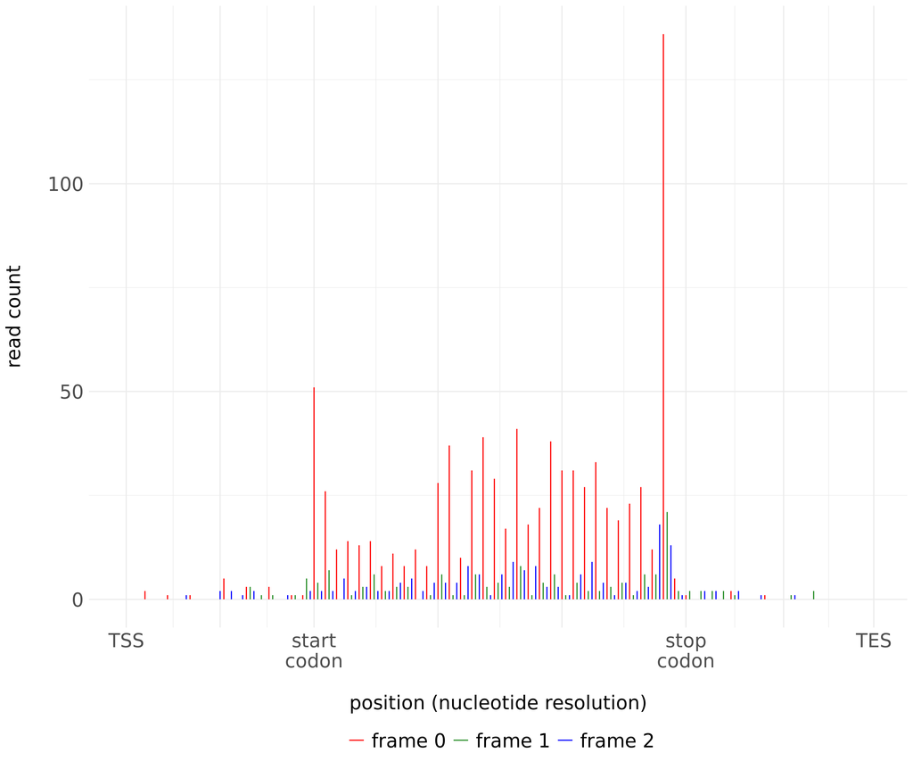

```r
readRDS("test_human_hek.html_plots/rds/sample1_nucl_4_profiles_P_sites_metagene_subcodon_all")[[1]]
```

Let’s now use Ribo-seQC to analyze different samples at once.

## Analyze multiple samples (yeast)

Let’s now create annotation for *Saccharomyces cerevisiae*. We will use a custom gtf file coming from the annotation in Ensembl 91, supplied with transcript boundaries from [3].

```r
download_testfile('test_yeast.2bit')
download_testfile('test_yeast.gtf')


prepare_annotation_files(annotation_directory = ".",
                         twobit_file = "test_yeast.2bit",
                         gtf_file = "test_yeast.gtf",scientific_name = "yeast.test",
                         annotation_name = "yeast_custom",export_bed_tables_TxDb = T,forge_BSgenome = T,create_TxDb = T)
```

[output not shown]

[output cut: 237 more lines]

[output not shown]

```
## Import genomic features from the file as a GRanges object ... OK
## Prepare the 'metadata' data frame ... OK
## Make the TxDb object ... OK
```

```
## Creating the TxDb object --- Done! Mon Jun 22 11:57:55 2020
## Extracting genomic regions ... Mon Jun 22 11:57:55 2020
## Extracting ids and biotypes ... Mon Jun 22 11:58:00 2020
## Defining most common start/stop codons ... Mon Jun 22 11:58:03 2020
## Rannot object created!   Mon Jun 22 11:58:37 2020
## Exporting annotation tables ... Mon Jun 22 11:58:37 2020
## Exporting annotation tables --- Done! Mon Jun 22 11:58:37 2020
```

```
## [1] "/fast/AG_Ohler/dharnet/Ribo-seQC/test_yeast.gtf_Rannot"
```

As before, we can explore different sequences and regions extracted from annotation.

```r
load_annotation("test_yeast.gtf_Rannot")

genome_seq[["II"]]
```

```
##   813184-letter "DNAString" instance
## seq: AAATAGCCCTCATGTACGTCTCCTCCAAGCCCTGTT...GGGTGTGGTGTGTGTGGGTGTGGTGTGTGGGTGTGT
```

```r
genome_seq[["Mito"]]
```

```
##   85779-letter "DNAString" instance
## seq: TTCATAATTAATTTTTTATATATATATTATATTATA...TACAGAAATATGCTTAATTATAATATAATATCCATA
```

```r
GTF_annotation$cds_txs
```

```
## GRangesList object of length 6692:
## $YAL069W
## GRanges object with 1 range and 3 metadata columns:
##       seqnames    ranges strand |    cds_id    cds_name exon_rank
##          <Rle> <IRanges>  <Rle> | <integer> <character> <integer>
##   [1]        I   335-649      + |         1        <NA>         1
##   -------
##   seqinfo: 17 sequences (1 circular) from an unspecified genome
##
## $`YAL068W-A`
## GRanges object with 1 range and 3 metadata columns:
##       seqnames    ranges strand |    cds_id    cds_name exon_rank
##          <Rle> <IRanges>  <Rle> | <integer> <character> <integer>
##   [1]        I   538-792      + |         2        <NA>         1
##   -------
##   seqinfo: 17 sequences (1 circular) from an unspecified genome
##
## $`YAL067W-A`
## GRanges object with 1 range and 3 metadata columns:
##       seqnames    ranges strand |    cds_id    cds_name exon_rank
##          <Rle> <IRanges>  <Rle> | <integer> <character> <integer>
##   [1]        I 2480-2707      + |         3        <NA>         1
##   -------
##   seqinfo: 17 sequences (1 circular) from an unspecified genome
##
## ...
## <6689 more elements>
```

```r
GTF_annotation$trann
```

```
## DataFrame with 7126 rows and 5 columns
##          gene_id   gene_biotype   gene_name transcript_id transcript_biotype
##      <character>    <character> <character>   <character>        <character>
## 1        YAL069W protein_coding          NA       YAL069W     protein_coding
## 2      YAL068W-A protein_coding          NA     YAL068W-A     protein_coding
## 3      YAL067W-A protein_coding          NA     YAL067W-A     protein_coding
## 4        YAL066W protein_coding          NA       YAL066W     protein_coding
## 5      YAL064W-B protein_coding          NA     YAL064W-B     protein_coding
## ...          ...            ...         ...           ...                ...
## 7122       Q0275 protein_coding        COX3         Q0275     protein_coding
## 7123   tM(CAU)Q2           tRNA          NA     tM(CAU)Q2               tRNA
## 7124        RPM1          ncRNA          NA          RPM1              ncRNA
## 7125       Q0297 protein_coding          NA         Q0297     protein_coding
## 7126   tT(XXX)Q2           tRNA          NA     tT(XXX)Q2               tRNA
```

We will now download three files corresponding to sample data from a TCP-seq experiment [4], where the three experiments aim at extracting RNA fragments covered by scanning ribosomes (SSU), elongating ribosomes (RS) and input material (input). Ribo-seQC analysis is followed by the creation of a report containing results for all the three experiments.

```r
download_testfile(filename = "test_yeast_TCP_input.bam")

download_testfile(filename = "test_yeast_TCP_RS.bam")

download_testfile(filename = "test_yeast_TCP_SSU.bam")

bam_filepath_y<-c("test_yeast_TCP_input.bam","test_yeast_TCP_RS.bam","test_yeast_TCP_SSU.bam")

RiboseQC_analysis(annotation_file="test_yeast.gtf_Rannot",bam_files = bam_filepath_y,fast_mode = T,report_file = "test_yeast_TCP.html",sample_names = c("input","RS","SSU"),dest_names = c("input","RS","SSU"),write_tmp_files = F)
```

```
## Loading annotation files in test_yeast.gtf_Rannot ... Mon Jun 22 11:58:38 2020
## Loading annotation files --- Done! Mon Jun 22 11:58:38 2020
## Extracting read lengths from test_yeast_TCP_input.bam ... Mon Jun 22 11:58:40 2020
## Extracting read lengths --- Done! Mon Jun 22 11:58:40 2020
## Analyzing BAM file: test_yeast_TCP_input.bam ... Mon Jun 22 11:58:40 2020
## Analyzing BAM file --- Done! Mon Jun 22 11:59:16 2020
## Building aggregate 5' profiles ... Mon Jun 22 11:59:16 2020
## Building aggregate 5' profiles --- Done! Mon Jun 22 12:03:13 2020
## Calculating P-sites offsets ... Mon Jun 22 12:03:13 2020
## Calculating P-sites offsets --- Done! Mon Jun 22 12:03:14 2020
## Calculating P-sites positions and junctions ... Mon Jun 22 12:03:14 2020
## Calculating P-sites positions and junctions --- Done! Mon Jun 22 12:03:16 2020
## Building aggregate P-sites profiles ... Mon Jun 22 12:03:16 2020
## Building aggregate P-sites profiles --- Done! Mon Jun 22 12:03:27 2020
## Exporting files ... Mon Jun 22 12:03:27 2020
## Exporting files --- Done! Mon Jun 22 12:03:31 2020
##
## Extracting read lengths from test_yeast_TCP_RS.bam ... Mon Jun 22 12:03:32 2020
## Extracting read lengths --- Done! Mon Jun 22 12:03:33 2020
## Analyzing BAM file: test_yeast_TCP_RS.bam ... Mon Jun 22 12:03:33 2020
## Analyzing BAM file --- Done! Mon Jun 22 12:03:59 2020
## Building aggregate 5' profiles ... Mon Jun 22 12:04:00 2020
## Building aggregate 5' profiles --- Done! Mon Jun 22 12:05:24 2020
## Calculating P-sites offsets ... Mon Jun 22 12:05:24 2020
## Calculating P-sites offsets --- Done! Mon Jun 22 12:05:25 2020
## Calculating P-sites positions and junctions ... Mon Jun 22 12:05:25 2020
## Calculating P-sites positions and junctions --- Done! Mon Jun 22 12:05:28 2020
## Building aggregate P-sites profiles ... Mon Jun 22 12:05:28 2020
## Building aggregate P-sites profiles --- Done! Mon Jun 22 12:05:44 2020
## Exporting files ... Mon Jun 22 12:05:44 2020
## Exporting files --- Done! Mon Jun 22 12:05:47 2020
##
## Extracting read lengths from test_yeast_TCP_SSU.bam ... Mon Jun 22 12:05:49 2020
## Extracting read lengths --- Done! Mon Jun 22 12:05:50 2020
## Analyzing BAM file: test_yeast_TCP_SSU.bam ... Mon Jun 22 12:05:50 2020
## Analyzing BAM file --- Done! Mon Jun 22 12:06:26 2020
## Building aggregate 5' profiles ... Mon Jun 22 12:06:26 2020
## Building aggregate 5' profiles --- Done! Mon Jun 22 12:08:23 2020
## Calculating P-sites offsets ... Mon Jun 22 12:08:23 2020
## Calculating P-sites offsets --- Done! Mon Jun 22 12:08:27 2020
## Calculating P-sites positions and junctions ... Mon Jun 22 12:08:27 2020
## Calculating P-sites positions and junctions --- Done! Mon Jun 22 12:08:41 2020
## Building aggregate P-sites profiles ... Mon Jun 22 12:08:41 2020
## Building aggregate P-sites profiles --- Done! Mon Jun 22 12:09:57 2020
## Exporting files ... Mon Jun 22 12:09:57 2020
## Exporting files --- Done! Mon Jun 22 12:10:00 2020
##
## Creating html report in test_yeast_TCP.html ... Mon Jun 22 12:10:00 2020
```

```
##
##
## processing file: riboseqc_template.Rmd
```

```
## output file: riboseqc_template.knit.md
```

```
##
## Output created: test_yeast_TCP.html
```

```
## Creating html report --- Done! Mon Jun 22 12:19:48 2020
```

The report allows to compare different samples side-by-side using tabs for different samples. For example, the 5’end profiles of different read lengths around start and stop codons can be visualized for different experiments. For the single plots:

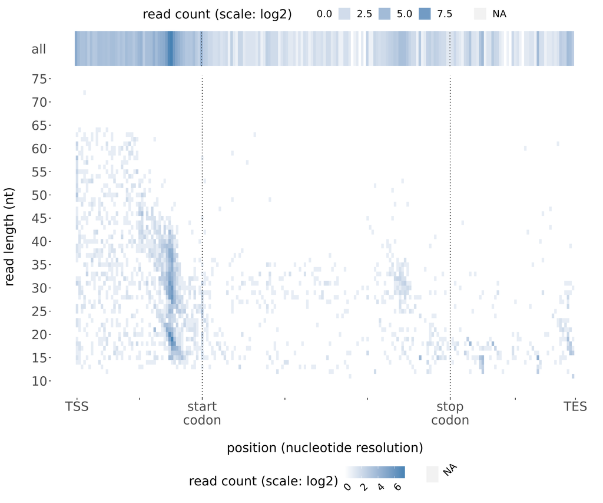

```r
as_ggplot(readRDS("test_yeast_TCP.html_plots/rds/SSU_nucl_4_profiles_fivepr_metagene_subcodon_log2")[[1]])
```

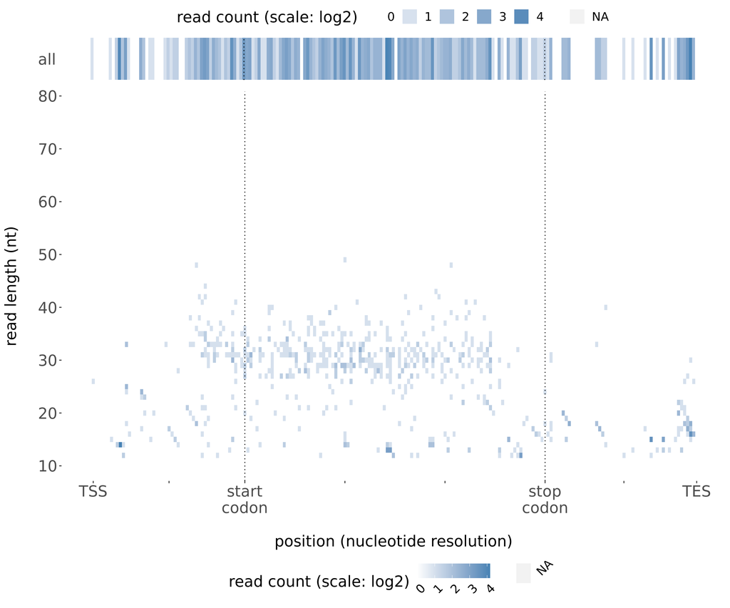

```r
as_ggplot(readRDS("test_yeast_TCP.html_plots/rds/RS_nucl_4_profiles_fivepr_metagene_subcodon_log2")[[1]])
```

## Analyze multiple samples (Arabidopsis)

We now create the annotation files for *Arabidopsis thaliana*. We will use a custom gtf file containing annotation of the Araport11 project (https://www.araport.org/), and non-coding RNA species from TAIR10.

```r
download_testfile("test_arabidopsis.2bit")
download_testfile("test_arabidopsis.gtf.gz")

prepare_annotation_files(annotation_directory = ".",
                         twobit_file = "test_arabidopsis.2bit",
                         gtf_file = "test_arabidopsis.gtf.gz",scientific_name = "arabidopsis.test",
                         annotation_name = "araport11_custom",export_bed_tables_TxDb = T,forge_BSgenome = T,create_TxDb = T)
```

[output not shown]

[output cut: 250 more lines]

[output not shown]

```
## Import genomic features from the file as a GRanges object ... OK
## Prepare the 'metadata' data frame ... OK
## Make the TxDb object ...
```

```
## OK
```

```
## Creating the TxDb object --- Done! Mon Jun 22 12:22:20 2020
## Extracting genomic regions ... Mon Jun 22 12:22:20 2020
## Extracting ids and biotypes ... Mon Jun 22 12:23:32 2020
## Defining most common start/stop codons ... Mon Jun 22 12:24:13 2020
## Rannot object created!   Mon Jun 22 12:26:33 2020
## Exporting annotation tables ... Mon Jun 22 12:26:33 2020
## Exporting annotation tables --- Done! Mon Jun 22 12:26:34 2020
```

```
## [1] "/fast/AG_Ohler/dharnet/Ribo-seQC/test_arabidopsis.gtf.gz_Rannot"
```

We will now download two sample datasets from a Ribo-seq experiments in Arabidopsis roots and shoots [5].

```r
annotation="test_arabidopsis.gtf.gz_Rannot"


download_testfile(filename = "test_arabidopsis_root.bam")
download_testfile(filename = "test_arabidopsis_shoot.bam")

bam_filepath=c("test_arabidopsis_root.bam","test_arabidopsis_shoot.bam")

RiboseQC_analysis(annotation_file=annotation,bam_files = bam_filepath,fast_mode = T,report_file = "test_root_shoots.html",dest_names = c("root","shoots"),sample_names = c("root","shoots"),write_tmp_files = F)
```

```
## Loading annotation files in test_arabidopsis.gtf.gz_Rannot ... Mon Jun 22 12:26:36 2020
## Loading annotation files --- Done! Mon Jun 22 12:26:37 2020
## Extracting read lengths from test_arabidopsis_root.bam ... Mon Jun 22 12:26:42 2020
## Extracting read lengths --- Done! Mon Jun 22 12:26:45 2020
## Analyzing BAM file: test_arabidopsis_root.bam ... Mon Jun 22 12:26:45 2020
## Analyzing BAM file --- Done! Mon Jun 22 12:27:12 2020
## Building aggregate 5' profiles ... Mon Jun 22 12:27:13 2020
## Building aggregate 5' profiles --- Done! Mon Jun 22 12:29:22 2020
## Calculating P-sites offsets ... Mon Jun 22 12:29:22 2020
## Calculating P-sites offsets --- Done! Mon Jun 22 12:29:24 2020
## Calculating P-sites positions and junctions ... Mon Jun 22 12:29:24 2020
## Calculating P-sites positions and junctions --- Done! Mon Jun 22 12:29:45 2020
## Building aggregate P-sites profiles ... Mon Jun 22 12:29:45 2020
## Building aggregate P-sites profiles --- Done! Mon Jun 22 12:31:05 2020
## Exporting files ... Mon Jun 22 12:31:05 2020
## Exporting files --- Done! Mon Jun 22 12:31:15 2020
##
## Extracting read lengths from test_arabidopsis_shoot.bam ... Mon Jun 22 12:31:19 2020
## Extracting read lengths --- Done! Mon Jun 22 12:31:20 2020
## Analyzing BAM file: test_arabidopsis_shoot.bam ... Mon Jun 22 12:31:20 2020
## Analyzing BAM file --- Done! Mon Jun 22 12:31:37 2020
## Building aggregate 5' profiles ... Mon Jun 22 12:31:39 2020
## Building aggregate 5' profiles --- Done! Mon Jun 22 12:33:25 2020
## Calculating P-sites offsets ... Mon Jun 22 12:33:25 2020
## Calculating P-sites offsets --- Done! Mon Jun 22 12:33:27 2020
## Calculating P-sites positions and junctions ... Mon Jun 22 12:33:27 2020
## Calculating P-sites positions and junctions --- Done! Mon Jun 22 12:33:51 2020
## Building aggregate P-sites profiles ... Mon Jun 22 12:33:51 2020
## Building aggregate P-sites profiles --- Done! Mon Jun 22 12:35:49 2020
## Exporting files ... Mon Jun 22 12:35:49 2020
## Exporting files --- Done! Mon Jun 22 12:35:58 2020
##
## Creating html report in test_root_shoots.html ... Mon Jun 22 12:35:58 2020
```

```
##
##
## processing file: riboseqc_template.Rmd
```

```
## output file: riboseqc_template.knit.md
```

```
##
## Output created: test_root_shoots.html
```

```
## Creating html report --- Done! Mon Jun 22 12:49:08 2020
```

For instance, we can visualize the amount of footprints mapping to different organelles and biotypes in the two samples:

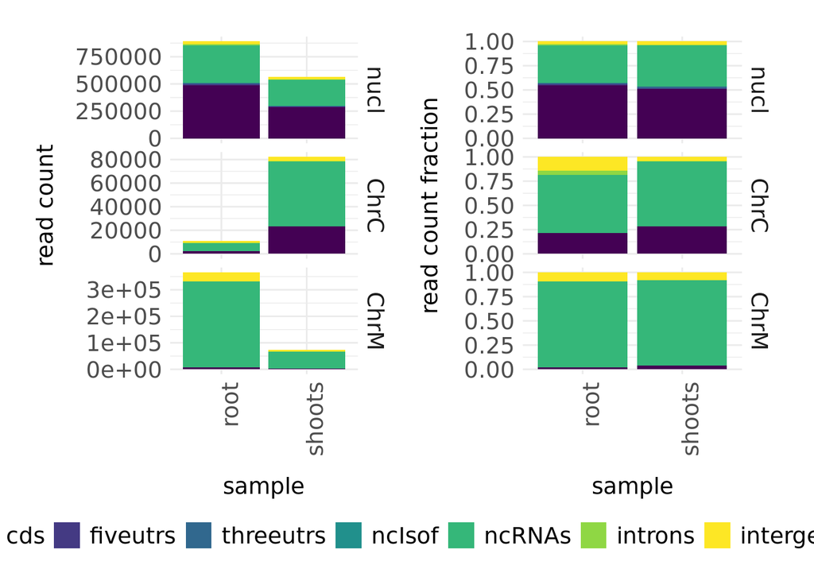

```r
readRDS("test_root_shoots.html_plots/rds/all_samples_1_readlocdist")[[1]]
```

or visualize z-scored positional codon usage values, calculated using A-site positions for chloroplast ribosomes in the shoots sample:

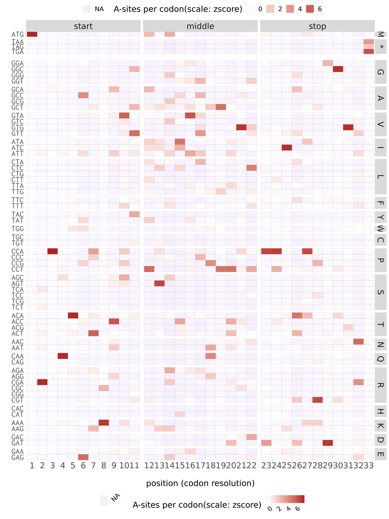

```r
as_ggplot(readRDS("test_root_shoots.html_plots/rds/shoots_ChrC_7_codonusage_positional_A-sites_per_codon_all_zscore")[[1]])
```

Much more information is available in the html reports, including read length distributions per biotype and compartment, statistics on codon usage, and analysis of the highest mapping positions in the genome.

## References

1. Ingolia, N.T. et al. (2009) Genome-wide analysis in vivo of resolution using ribosome profiling. Science 324, 218–223
2. Calviello, L. et al. (2015) Detecting actively translated open reading frames in ribosome profiling data. Nat. Methods 13, 1–9
3. Daechan P. et al. (2014) Simultaneous mapping of transcript ends at single-nucleotide resolution and identification of widespread promoter-associated non-coding RNA governed by TATA elements, Nucleic Acids Research, Volume 42, Issue 6, 1 April 2014, Pages 3736-3749
4. Archer, S.K. et al. (2016) Dynamics of ribosome scanning and recycling revealed by translation complex profiling. Nature 535, 570–574
5. Hsu, P.Y. et al. (2016) Super-resolution ribosome profiling reveals novel translation events in Arabidopsis. PNAS, 113, E7126–E7135